# **ggplot2: Elegante Datenvisualisierung**

#### Verwendete Daten und Ästhetiken: `aes()`

Wie in den oben gezeigten Grafiken zu sehen ist, sind die verwendeten Variablen immer in einem untergeordneten `aes()`-Befehl angegeben. Dies ist ein **essenzieller Schritt**, um korrekte Ergebnisse von ggplot zu erreichen, und häufig die erste zu überprüfende Stelle, sollte es zu Problemen in der Grafik-Erstellung kommen. Dieses Ästhetik-Argument lässt sich dabei ebenfalls entweder *global* in der `ggplot()`-Funktion, oder lokal in der jeweiligen Visualisierungs-Funktion (z.B. `geom_point()`) festlegen.  
Wie oben zu sehen, lassen sich über diese `aes()`-Funktion dabei nicht nur die verwendeten X- und Y-Variablen, sondern auch andere Ästhetik-Argumente wie z.B. die Farbe oder die Füllung der zu erzeugenden Objekte (über `colour =` und `fill =` respektive) festlegen. Neben `colour` und `fill` gibt es dabei noch eine ganze Reihe an möglichen Ästhetiken, die sich für das Plotten der Graphen verändern lassen (s. Abschnitt Präsentation und Farben für mehr Beispiele).

Insbesondere für `colour` und `fill` ist dabei zu beachten, dass diese sowohl innerhalb der `aes()`-Funktion, als auch außerhalb dieser Funktion stehen können. Während eine Nutzung innerhalb von `aes()` dabei die Farbe als Variable des Datensatzes definiert, führt eine Nutzung außerhalb von `aes()` dazu, dass die Farbe als ein bestimmter Farbwert definiert wird:

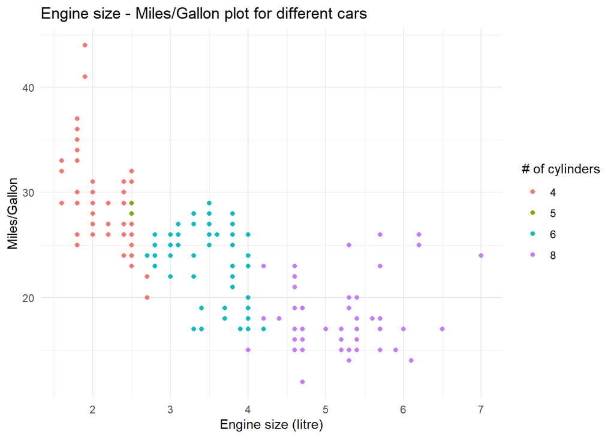

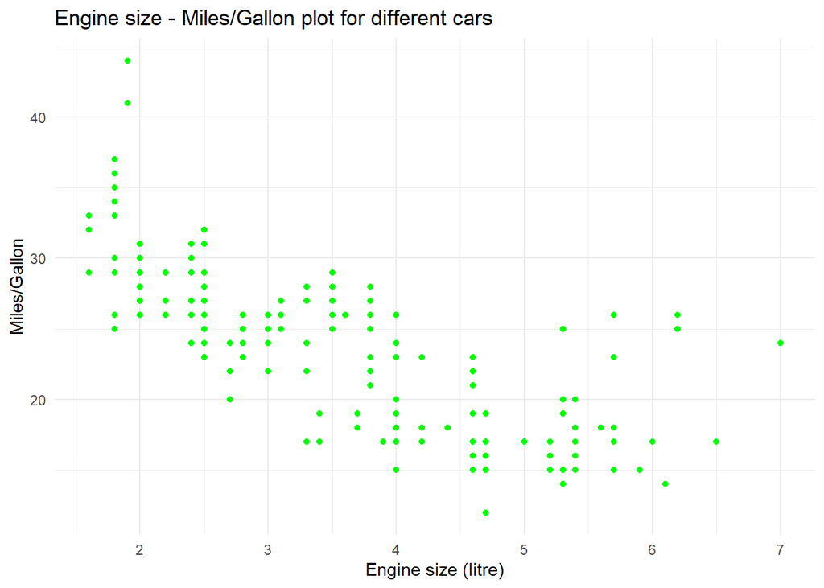

```r
# colour innerhalb aes -> Farbe basierend auf Variable
mpg %>% mutate(cyl = as.factor(cyl)) %>%
  ggplot(aes(x = displ, y = hwy)) +
  geom_point(aes(colour = cyl)) + theme_minimal() +
  labs(title = "Engine size - Miles/Gallon plot for different cars",
       x = "Engine size (litre)", y = "Miles/Gallon", colour = "# of cylinders")

# colour außerhalb aes -> Farbe als definitiver Wert
mpg %>% mutate(cyl = as.factor(cyl)) %>%
  ggplot(aes(x = displ, y = hwy)) +
  geom_point(colour = "green") + theme_minimal() +
  labs(title = "Engine size - Miles/Gallon plot for different cars",
       x = "Engine size (litre)", y = "Miles/Gallon", colour = "# of cylinders")
```

Die Unterscheidung zwischen `colour` und `fill` ist dabei ein Thema für sich. Generell lässt sich festhalten, dass `fill` sich auf die innere Füllung eines Objektes bezieht (bspw. Bars), während `colour` die Farbe der Umrandung spezifiziert. Die Standard-Punkte von z.B. `geom_point()` sind dabei eine der markantesten Ausnahmen, da sie nur ein `colour`- und kein `fill`-Argument besitzen.

### Visualisierungen: `geom_...()`

Wie bereits in vielen der genannten Beispiele zu sehen ist, bauen die `geom_...()`-Funktionen auf die gelieferten Leinwand-Grundlagen auf, und bieten die eigentliche Visualisierung der Daten. Wer einmal in RStudio “geom_” eingibt, wird dabei in den vorgeschlagenen Funktionen sehen, dass ggplot2 eine ganze Reihe an Visualisierungsmöglichkeiten anbietet.  
Bei der Wahl der jeweiligen Visualisierung ist dabei jedoch immer darauf zu achten, wie viele Argumente die jeweilige Funktion benötigt. Insbesondere Barplots und Histogramme benötigen beispielsweise nur eine x-Variable, da sie die Y-Variable selbstständig aus der Häufigkeitsverteilung von X erzeugen. Sollte dennoch (z.B. als globale Option) eine Y-Variable festgelegt werden, wird sich die Funktion bei Ausführung mit einer Fehlermeldung verabschieden.

Wie ebenfalls bereits zu Beginn gezeigt, können mehrere dieser Visualisierungsmöglichkeiten innerhalb desselben Plots genutzt werden, um beispielsweise eine Punkteverteilung in Kombination mit einer Regressionsgeraden zu visualisieren. Auf diese Weise lassen sich auch unterschiedliche X- und Y-Variablen gleichzeitig abbilden, auch wenn dadurch unter Umständen die Skalenbreite leidet.

Bei der Nutzung mehrerer Visualisierungs-Arten innerhalb derselben Grafik ist dabei wiederum der modulare Aufbau von ggplot zu berücksichtigen: **Das zuletzt angegebene Objekt überlagert immer die vorangegangenen Objekte**:

[figure not shown]

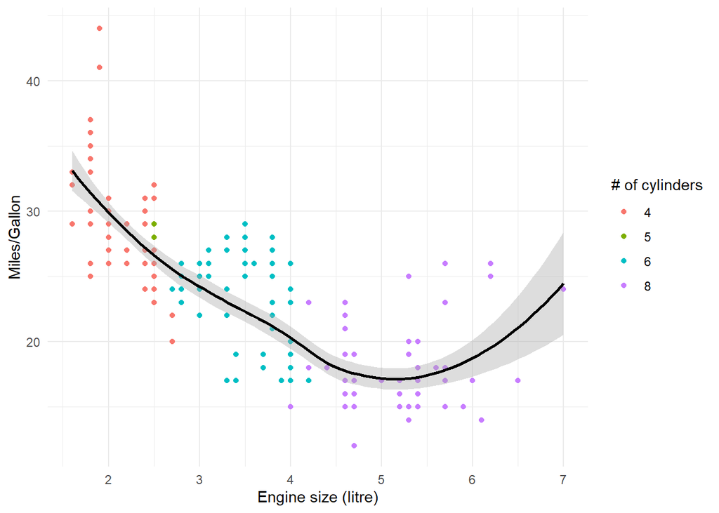

```r
# Punkte überlagern Linie
mpg %>% mutate(cyl = as.factor(cyl)) %>%
  ggplot(aes(x = displ, y = hwy)) +
  geom_smooth(colour = "black", fill = "dark gray") + geom_point(aes(colour = cyl)) + theme_minimal() +
  labs(x = "Engine size (litre)", y = "Miles/Gallon", colour = "# of cylinders")
# Linie überlagert Punkte
mpg %>% mutate(cyl = as.factor(cyl)) %>%
  ggplot(aes(x = displ, y = hwy)) +
  geom_point(aes(colour = cyl)) + theme_minimal() + geom_smooth(colour = "black", fill = "dark gray") +
  labs(x = "Engine size (litre)", y = "Miles/Gallon", colour = "# of cylinders")
```

#### Weitere wichtige Funktionen

Neben den `geom_...()`-Funktionen lassen sich noch andere Merkmale des Graphen durch Funktionen definieren. Die bereits in den vorangegangenen Graphen benutzte `labs()`-Funktion ermöglicht beispielsweise eine manuelle Veränderung der Benennungen für Achsen, Legenden oder den gesamten Plot.  
Über diese Zusatzfunktionen lassen sich beispielsweise bequem Skalentransformationen durchführen (z.B. `scale_x_log10()`) oder Datenformate ändern (z.B. `scale_y_date()`), bestimmte Farbpaletten festlegen (z.B. `scale_colour_brewer()`, alternativ `scale_fill_manual()` für eignene Skalen) oder Themen für die Gesamtpräsentation des Plots (z.B. `theme_minimal`) festlegen.

## Alle Informationen auf einmal

Wie bereits erwähnt, sind `colour` und `fill` nicht die einzigen Attribute, die sich variabel festlegen lassen. Auch die Darstellungsform von Punkten/Linien, deren Größe und Alpha-Level lassen sich frei anhand von Drittvariablen festlegen. Um dies zu demonstrieren folgt nun der Versuch, einen Großteil der restlichen Variablen des mpg-Datensatzes zusätzlich zu den bekannten X- und Y-Variablen in einem einzigen Plot zu visualisieren. Das Ergebnis ist nicht schön, zeigt aber gut, wozu ggplot bei richtiger Anwendung in der Lage ist:

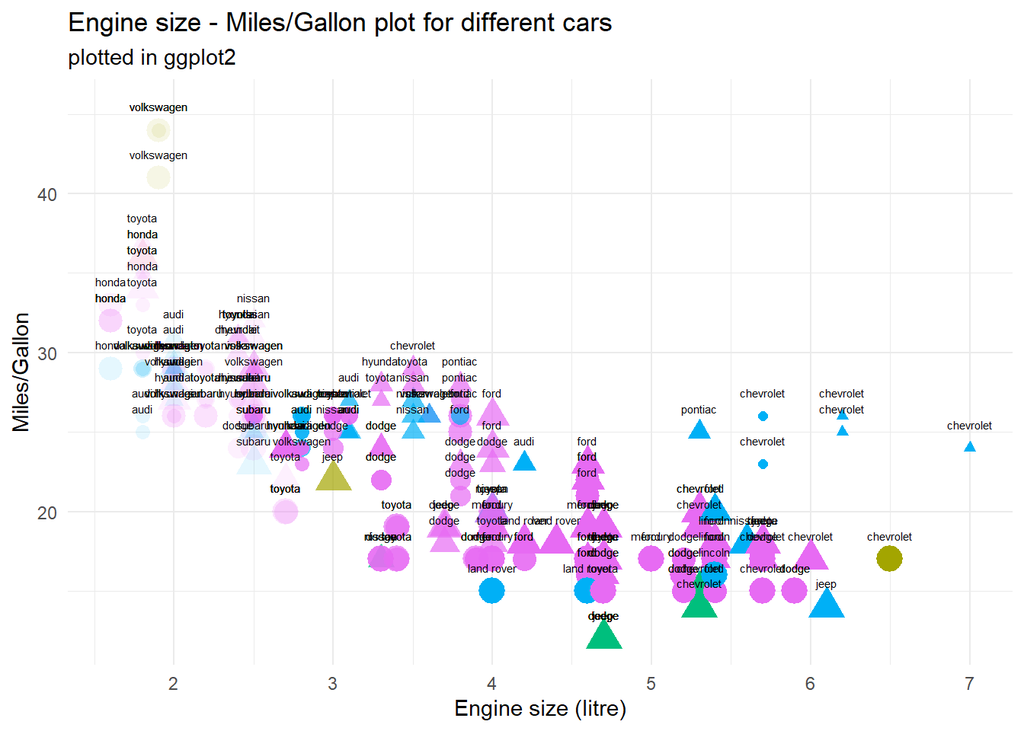

```r
mpg %>% mutate(cyl = as.factor(cyl), year = as.factor(year)) %>%
  ggplot(aes(x = displ, y = hwy)) + # X- und Y-Variable
  geom_point(aes(alpha = cyl, # Durchsichtigkeit basierend auf Zylinderzahl
                 shape = year, # Jahr als Punktform
                 colour = fl, # Treibstofftyp als Farbe
                 size = class # Fahrzeugklasse als Größe
                 )) +
  geom_text(aes(label = manufacturer), size = 2, nudge_y = 1.5) + # Hersteller als Name
  theme_minimal() + theme(legend.position = "none") +
  labs(title = "Engine size - Miles/Gallon plot for different cars",
       subtitle = "plotted in ggplot2",
       x = "Engine size (litre)", y = "Miles/Gallon", colour = "# of cylinders")
```

## Präsentation und Farben

Wie bereits erwähnt, lassen sich die Farbpaletten und die gesamte thematische Präsentation des letztendlich entstehenden Graphen jederzeit über Befehle anpassen, wodurch Grafiken unter Umständen deutlich lesbarer werden können.  
Beide dieser Varianten lassen sich dabei durch Ergänzungs-Packages weiter ausbauen, weshalb ich sie hier explizit herausgreifen will:

Für Farben bietet sich das Package `RColorBrewer` an, das standardmäßig mit ggplot2 geliefert wird und eine Reihe an schönen Farbpaletten anbietet, die sich in ggplot über den Befehl `scale_fill_brewer(palette = "")` einfügen lassen. Eine Übersicht dieser Farbpaletten in Aktion findet sich beispielsweise hier: http://applied-r.com/rcolorbrewer-palettes/

Für weitere Themes bietet sich das (manuell zu installierende) Package `ggthemes` an, das die mitgelieferten ggplot-Themen um eine große Reihe visuell unterschiedlicher und von klassischen Programmen/Nachrichtendiensten inspirierter Grafik-Themen anbietet. Beispiele finden sich hier: https://github.com/jrnold/ggthemes#readme  
Wer sein eigenes Theme erstellen und abspeichern will, dem sei das Package `ggCorpIdent` ans Herz gelegt, das genau dies ermöglicht: https://github.com/INWTlab/ggCorpIdent

## Spezialisierte Anwendungen und Tricks

#### Tidyverse

Das ggplot2-Package ist Teil des Tidyverse. Das bedeutet, dass alle Funktionen der anderen Tidyverse-Packages relativ reibungslos in ggplot-Berechnungen integriert werden können.  
Ein zusätzlicher Vorteil dieses Umstandes ist, dass ggplot nativ mit dem `%>%`-Operator kompatibel ist. Daten können somit für die grafische Aufbereitung verändert und gefiltert, und dann in die ggplot()-Funktion geleitet werden, ohne dass die dafür notwendigen Veränderungen zwangsweise innerhalb des Quelldatensatzes überschrieben oder sonst wie abgespeichert werden müssen.

#### Sub-Plots anhand von Variablen

Mithilfe des Argumentes `facet_grid()` (bzw. `facet_wrap()` für ein [weniger striktes Schaubild](https://www.statology.org/facet_wrap-vs-facet_grid-in-r/)) lassen sich Subgraphen anhand von Drittvariablen erstellen. Wie oben zu sehen ist, kommt man manchmal an einen gewissen Punkt, an dem sich die Menge an Informationen nicht mehr verlässlich innerhalb eines einzelnen Graphen darstellen lässt.  
Die Facetten-Plots sind dabei eine gute Möglichkeit, Grafiken anhand einer oder zwei weiterer Drittvariablen aufzuteilen. Die Generierung funktioniert dabei analog zu Regressionslogik: `facet_grid(vertikaleDrittvariable ~ horizontaleDrittvariable)`, wobei auch nur eine einzige Drittvariable gewählt werden kann, indem die andere durch einen Punkt ersetzt wird: `facet_grid(. ~ horizontaleDrittvariable)`.

Während `facet_wrap()` dabei nur Grafiken für die vertikal~horizontal-Paare anzeigt, für die sich tatsächlich Daten finden lassen, erzeugt `facet_grid()` einen Plot für jede mögliche Wertkombination - und kann so auch leere Plots erzeugen.

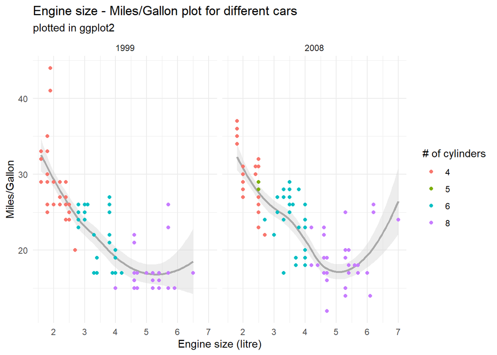

```r
# facet_wrap mit einer Drittvariable (Jahr)
mpg %>% mutate(cyl = as.factor(cyl)) %>%
  ggplot(aes(x = displ, y = hwy)) +
  geom_smooth(colour = "dark gray", fill = "light gray") + geom_point(aes(colour = cyl)) + theme_minimal() +
  labs(title = "Engine size - Miles/Gallon plot for different cars",
       subtitle = "plotted in ggplot2",
       x = "Engine size (litre)", y = "Miles/Gallon", colour = "# of cylinders") +
  facet_wrap(.~year)
```

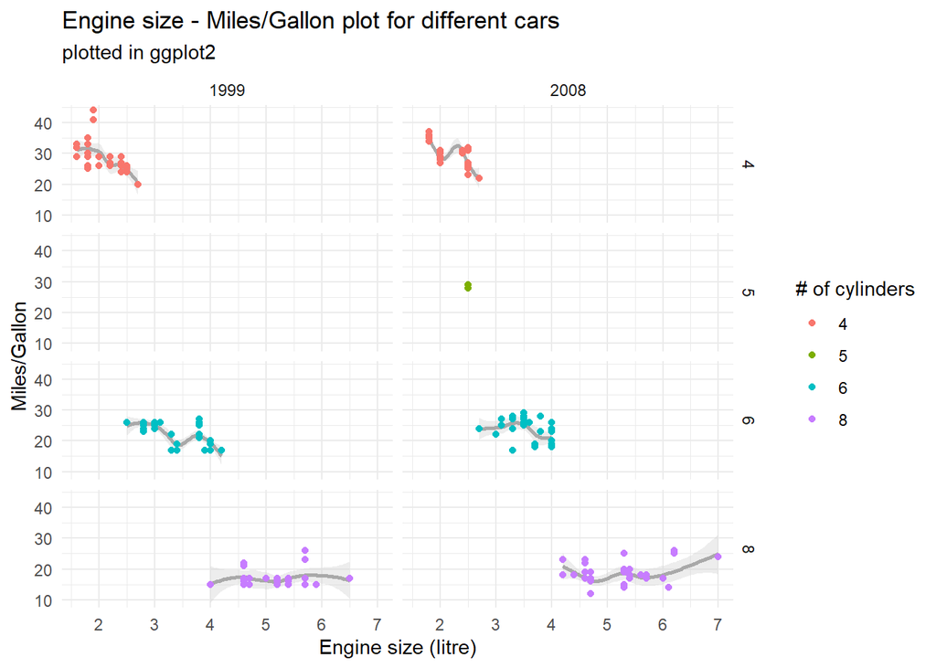

```r
# facet_grid mit zwei Drittvariablen (# Zylinder ~ Jahr) - leeres Feld für 1999 - 5 Zylinder
mpg %>% mutate(cyl = as.factor(cyl)) %>%
  ggplot(aes(x = displ, y = hwy)) +
  geom_smooth(colour = "dark gray", fill = "light gray") + geom_point(aes(colour = cyl)) + theme_minimal() +
  labs(title = "Engine size - Miles/Gallon plot for different cars",
       subtitle = "plotted in ggplot2",
       x = "Engine size (litre)", y = "Miles/Gallon", colour = "# of cylinders") +
  facet_grid(cyl~year)
```

#### Mehrere Achsen in einem Plot

Es kann in bestimmten Nischen-Fällen durchaus zu Situationen kommen, in denen zwei unterschiedliche Variablen mit unterschiedlichen Werten (bspw. Punktewolke zw. 10-100 und Histogramm zw. 1-5) im selben Graph visualisiert werden sollen. Dies ist mit ggplot inzwischen ebenfalls möglich, wenn auch nur über Umwege:

Wie bereits zu Beginn erklärt, werden die Achsengrößen in ggplot global anhand der gegebenen Variablen festgelegt. Zwar ist es durchaus möglich, mehrere Variablen mit unterschiedlichen Achsenlängen in denselben Graphen zu packen, die Reichweite der jeweiligen Achse reicht dann jedoch vom Minimum der kleinsten Variable bis zum Maximum der größten Variable.  
Der Workaround hierfür ist es, die gewünschte zweite Variable so zu transformieren, dass sie den selben Wertebereich wie die erste Variable einnimmt - und dann über einen Befehl wie `scale_y_continuous(sec.axis = sec_axis(~ . FORMEL))` die für diese zweite Variable zuständige Achse zurück auf das ursprüngliche Niveau zu transformieren:

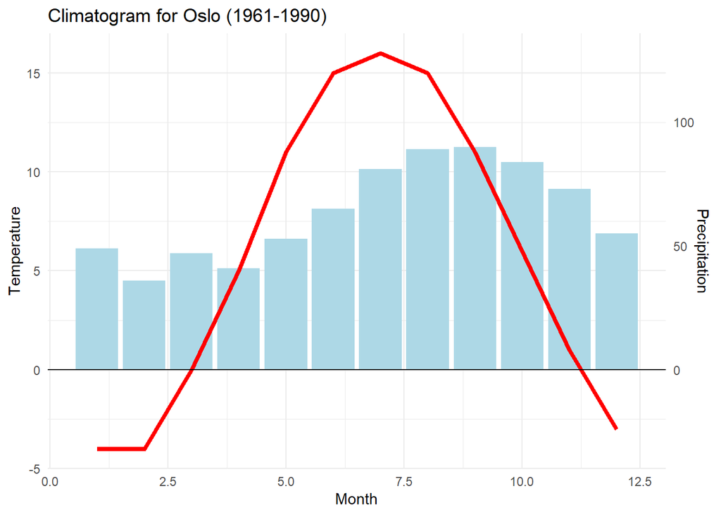

```r
# data frame mit zwei gleichzeitig zu präsentierenden Y-Werten:
climate <- data.frame(month = 1:12,
                      temp = c(-4,-4,0,5,11,15,16,15,11,6,1,-3),
                      precip = c(49,36,47,41,53,65,81,89,90,84,73,55))

climate %>% mutate(precip = precip / 8) %>% # Recodierung Feuchtigkeit
  ggplot(aes(x = month)) +
  geom_col(aes(y = precip), fill = "light blue") + # Feuchtigkeit
  geom_line(aes(y = temp), colour = "red", size = 1.5) + # Temperatur
  scale_y_continuous("Temperature", sec.axis = sec_axis(~ . * 8, name = "Precipitation")) + #Re-Recodierung zweite Y-Achse
  labs(x = "Month", title = "Climatogram for Oslo (1961-1990)") + # Titel
  geom_hline(yintercept = 0) + theme_minimal() # Grafikspielereien
```

Die Bandbreite an Grafikoptionen und Features von ggplot2 lässt sich dabei durch zusätzliche Packages noch weiter vergrößern. Beispiele für Visualisierungsmöglichkeiten finden sich überall im Internet, z.B. hier: https://r-statistics.co/Top50-Ggplot2-Visualizations-MasterList-R-Code.html

Wie zu beinahe jedem anderen hier besprochenen Thema auch, gibt es für ggplot2 ebenfalls ein [umfangreiches Cheatsheet](https://github.com/rstudio/cheatsheets/blob/main/data-visualization-2.1.pdf). Zudem lässt sich für jede der Subfunktionen (`geom_point()`, `labs()`, …) eine eigene, detaillierte Hilfeseite über das gewohnte `?` aufrufen.

Die [ggplot2-Webseite](https://ggplot2.tidyverse.org/) und das [R-Cookbook](http://www.cookbook-r.com/Graphs/) sind ebenfalls eine gute Anlaufstelle für weitere Informationen und ANwendungsbeispiele.

Insbesondere für ggplot gilt zudem ein weiterer Punkt: Solltet ihr mit der Anwendung von ggplot-Funktionen Probleme haben, empfiehlt sich immer ein kurzer Blick ins Internet, z.B. auf StackOverflow, da dort viele der größten und kleinsten Probleme von ggplot bereits angesprochen und gelöst wurden.

Bei Fragen und je nach Schwere der auftretenden Probleme kann ich auch im Tutorium zu Helfen versuchen. Ich habe zwar alles hier Beschriebene auf meiner Maschine getestet, das ist jedoch keine 100%ige Funktionsgarantie.

**Letzte Modifikation:** 2022-05-11 20:23:12, R version 4.2.0  
**.Rmd-Datei dieses Dokuments:** https://github.com/fallenEngels/R-basics/blob/main/ggplot.Rmd